# Algorytmy danych geoprzestrzennych

Relacje przestrzenne

Krzysztof Dyba

## Relacja przestrzenna

Relacja przestrzenna określa sposób w jaki obiekty są ze sobą powiązane pod względem lokalizacji, odległości i interakcji w przestrzeni. Relacje te opisują wzajemne zależności pomiędzy obiektami.

## Rodzaje relacji przestrzennych

- Topologiczne – opisują zależności pomiędzy obiektami, np. przyleganie do siebie dwóch działek katastralnych
- Odległościowe – opisują odległość między obiektami, np. odległość między dwoma miastami czy lokalizacja najbliższego szpitala
- Wzorce i rozkład przestrzenny – opisują rozmieszczenie obiektów w przestrzeni (tj. czy są skupione, równomiernie rozłożone lub rozproszone losowo), np. rozmieszczenie szkół w mieście

## Zastosowania

- Zapytania przestrzenne – wybieranie obiektów na podstawie ich relacji przestrzennej z innymi obiektami, np. wybierz wszystkie budynki, które znajdują się w strefie 1 km od centrum miasta
- Analiza przestrzenna – modelowanie zjawisk w kontekście geograficznym, np. wyznaczenie obszaru, który dotknięty jest przez negatywny czynnik (mapa zanieczyszczeń)
- Połączenia przestrzenne tabel – obiekty dopasowywane są na podstawie określonej relacji topologicznej, a nie klucza (ID) w tabeli

## Predykaty

**Predykat** (*predicate*) to:

- wyrażenie opisujące pewne właściwości lub relacje
- funkcja orzekająca o spełnieniu jakiegoś warunku (sprawdza go i zwraca prawdę bądź fałsz)

**Przykład:** Funkcja sprawdzająca czy liczba jest parzysta.

## Predykaty przestrzenne

**Predykaty przestrzenne** (geometryczne) to wyrażenia logiczne lub warunki opisujące relacje topologiczną między obiektami w przestrzeni.

**Przykłady:**

- Obiekt A przechodzi przez obiekt B
- Obiekt A jest całkowicie zawarty w obiekcie B
- Obiekt A całkowicie zawiera obiekt B
- Obiekty A i B nie przecinają się ani nie są styczne

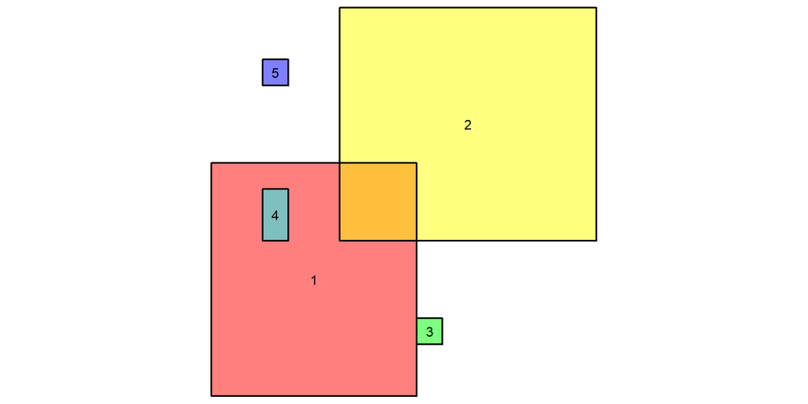

## Predykaty przestrzenne

- Zawiera (*Contains*)
- Przechodzi (*Crosses*)
- Pokrywa (*Covers*)
- Pokryty przez (*Coveredby*)
- Rozłączny (*Disjoint*)
- Równy (*Equals*)
- Przecina (*Intersects*)
- Nakłada (*Overlaps*)
- Dotyka (*Touches*)
- Wewnątrz (*Within*)

## Zawiera

Jedna geometria całkowicie zawiera w sobie inną geometrię.

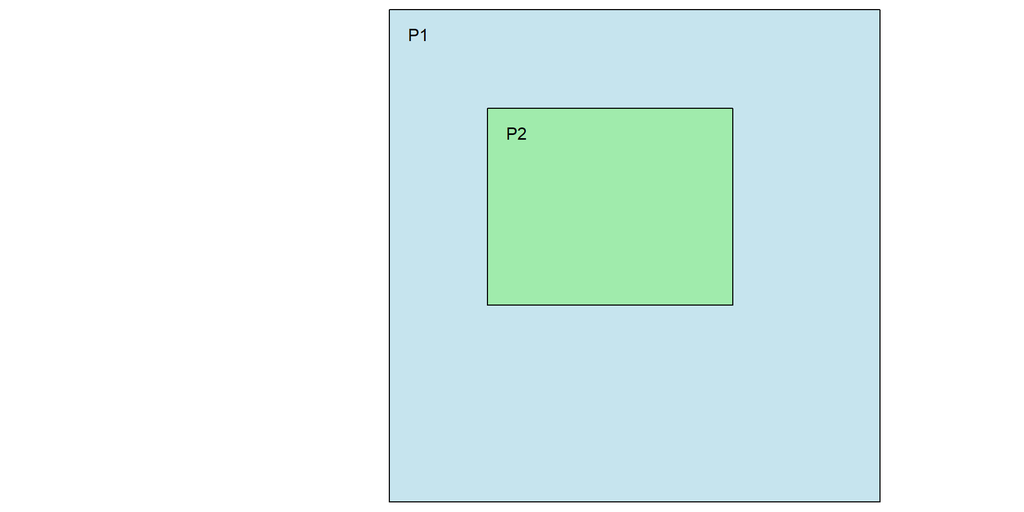

```
                          P1 zawiera P2: PRAWDA
                          P2 zawiera P1: FAŁSZ
```

**Przykład:** Powiat zawierający miasto.

## Przechodzi

Dwie geometrie mają częściowo wspólne punkty (nie wszystkie). Zwykle dotyczy przecięcia linii i poligonu lub dwóch linii.

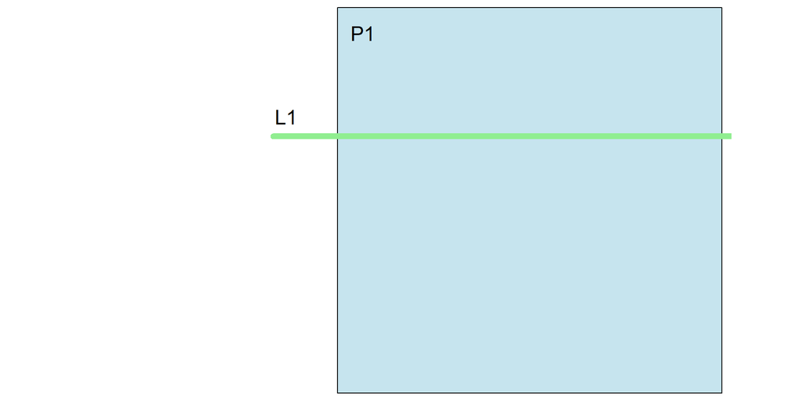

```
            L1 przechodzi przez P1: PRAWDA
            P1 przechodzi przez L1: PRAWDA
```

**Przykład:** Droga przebiegająca częściowo przez las i miasto.

## Pokrywa

Jedna geometria całkowicie obejmuje drugą, ale nie oznacza to, że są identyczne (geometria pokrywająca drugą może być większa).

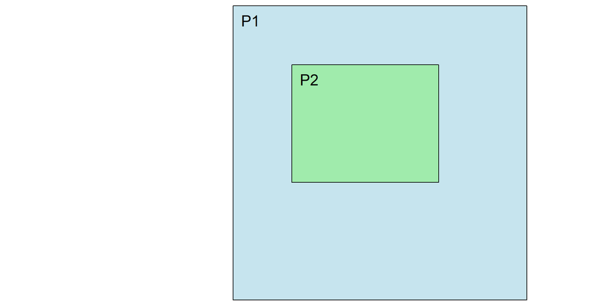

```
              P1 pokrywa P2: PRAWDA
              P2 pokrywa P1: FAŁSZ
```

**Przykład:** Powiat pokrywający miasto.

## Pokryty przez

Jedna geometria znajduje się całkowicie wewnątrz innej geometrii, ale większa geometria może wykraczać poza nią.

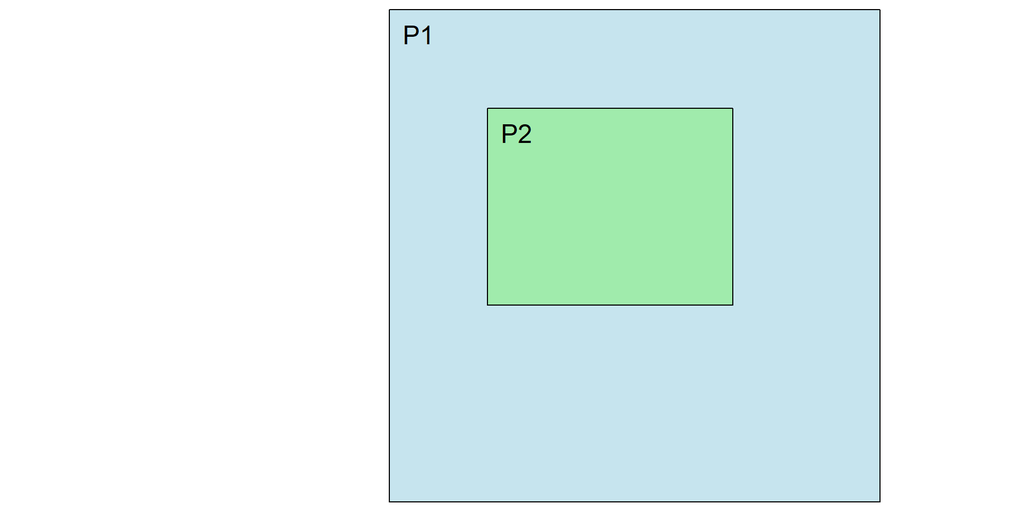

```
              P1 jest pokryty przez P2: FAŁSZ
              P2 jest pokryty przez P1: PRAWDA
```

**Przykład:** Miasto pokryte jest przez powiat.

## Rozłączny

Dwie geometrie nie mają ze sobą żadnego wspólnego punktu (nie przecinają się i nie stykają, tj. są rozdzielone).

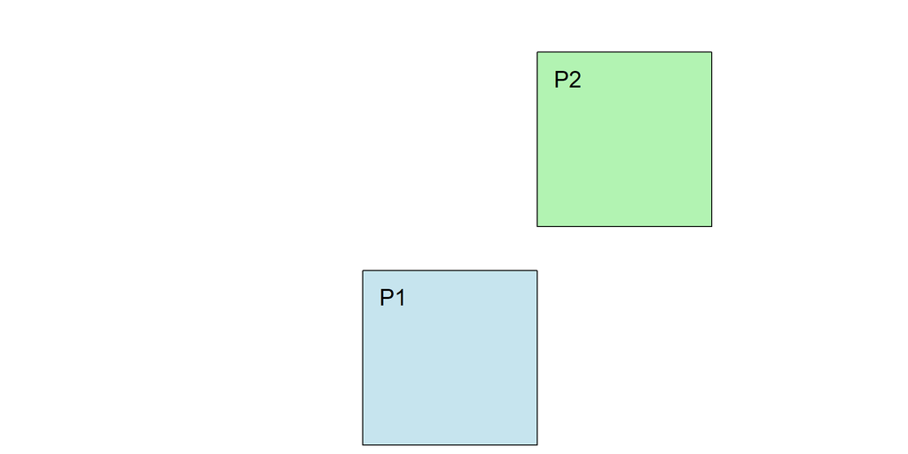

```
              P1 jest rozłączny od P2: PRAWDA
              P2 jest rozłączny od P1: PRAWDA
```

**Przykład:** Dwa budynki w różnych częściach miasta.

## Równy

Dwie geometrie są dokładnie takie same (mają identyczne kształt i położenie).

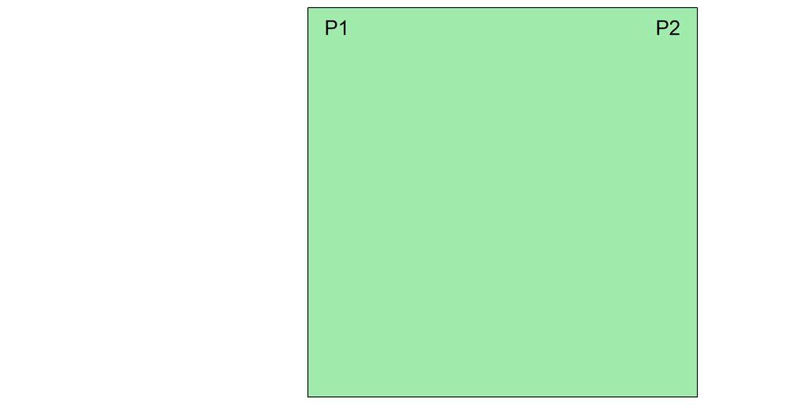

```
              P1 jest równy P2: PRAWDA
              P2 jest równy P1: PRAWDA
```

**Przykład:** Budynek zajmujący całą powierzchnię działki katastralnej.

## Przecina

Dwie geometrie mają co najmniej jeden punkt wspólny.

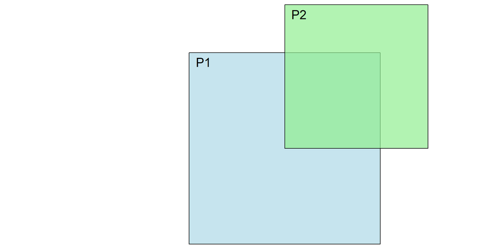

```
                  P1 przecina P2: PRAWDA
                  P2 przecina P1: PRAWDA
```

**Przykład:** Droga przecinająca linię kolejową (przejazd kolejowy).

## Nakłada

Dwie geometrie dzielą części swojego wnętrza, ale nie całość (częściowo się nakładają).

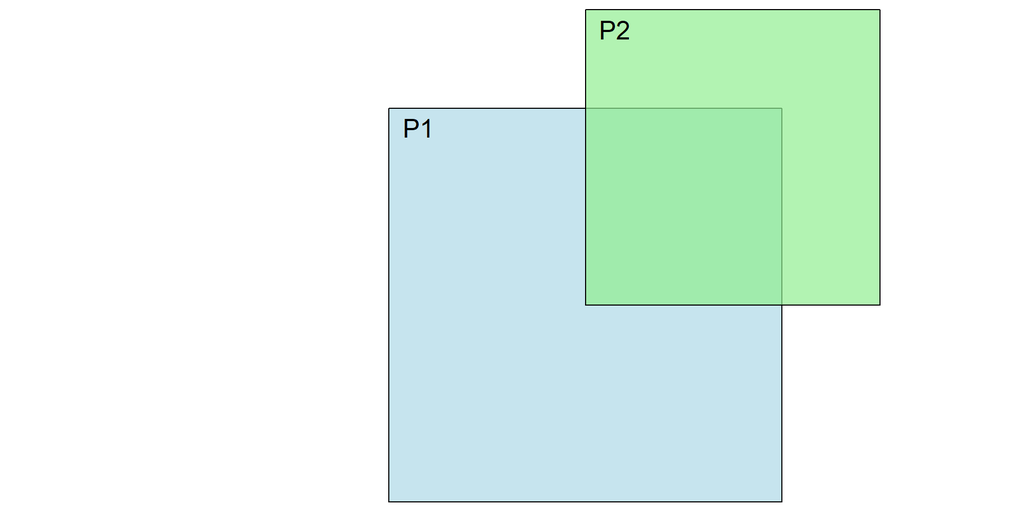

```
            P1 nakłada się z P2: PRAWDA
            P2 nakłada się z P1: PRAWDA
```

**Przykład:** Obszar parku narodowego pokrywający się częściowo z obszarem lasu.

## Dotyka

Dwie geometrie mają wspólną granicę, ale nie pokrywają się (stykają się tylko na krawędzi).

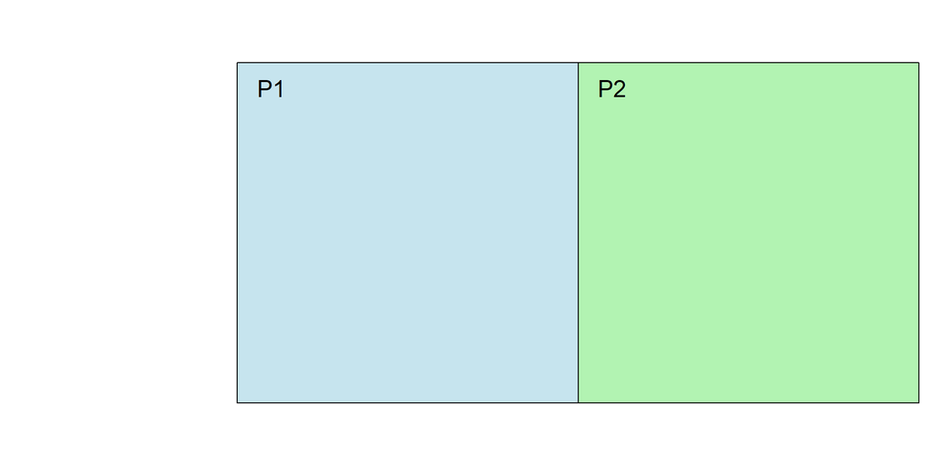

```
                    P1 dotyka P2: PRAWDA
                    P2 dotyka P1: PRAWDA
```

**Przykład:** Dwie sąsiadujące ze sobą działki katastralne.

## Wewnątrz

Jedna geometria jest całkowicie zawarta w innej geometrii.

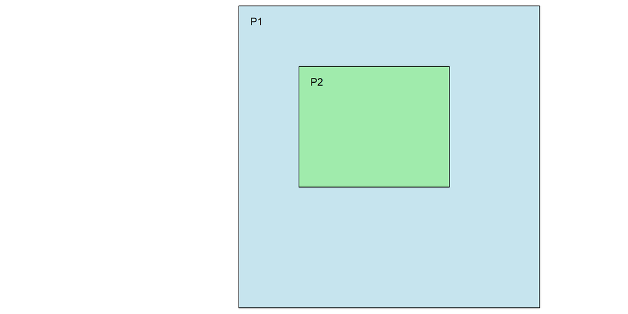

```
                    P1 jest wewnątrz P2: FAŁSZ
                    P2 jest wewnątrz P1: PRAWDA
```

**Przykład:** Miasto znajdujące się w powiecie.

## Implementacje

Predykaty przestrzenne są implementowane w różnym oprogramowaniu geoinformacyjnym, w tym:

- [GEOS](https://libgeos.org/doxygen/classgeos_1_1geom_1_1Geometry.html) (QGIS, Grass GIS, terra, sf, shapely)
- [JTS Topology Suite](https://locationtech.github.io/jts/jts-features.html)
- [Boost.Geometry](https://beta.boost.org/doc/libs/1_82_0/libs/geometry/doc/html/geometry/reference/spatial_indexes/group__predicates.html)
- [S2](http://s2geometry.io/about/overview)
- [ArcGIS](https://developers.arcgis.com/documentation/spatial-analysis-services/geometry-analysis/spatial-relationship/)
- [PostGIS](https://postgis.net/docs/using_postgis_query.html)

## Model *DE-9IM*

## Model DE-9IM

Model DE-9IM (*Dimensionally Extended 9 Intersection Model*) to model topologiczny stosowany w systemach informacji geograficznej do opisu relacji przestrzennych między dwoma obiektami geometrycznymi, takimi jak punkty, linie i poligony.

Jest fundamentalnym konceptem w topologii przestrzennej.

## Założenia

Model DE-9IM testuje przecięcia między wnętrzem, granicą i zewnętrzem dwóch geometrii definiowanych w następujący sposób:

- wnętrze (*Interior*) – główna część obiektu (rdzeń)
- granica (*Boundary*) – krawędź obiektu
- zewnętrze (*Exterior*) – przestrzeń poza obiektem

**Uwaga!** W przypadku linii, granicą jest punkt początkowy oraz końcowy linii. Natomiast punkt w ogóle nie posiada granic.

## Założenia

Model określa wymiar każdego możliwego przecięcia między tymi częściami w postaci macierzy 3 x 3, w której każda komórka reprezentuje przecięcie dwóch obiektów (A i B).

|  | **I(B)** | **B(B)** | **E(B)** |
| --- | --- | --- | --- |
| **I(A)** | I/I | I/B | I/E |
| **B(A)** | B/I | B/B | B/E |
| **E(A)** | E/I | E/B | E/E |

## Założenia

Komórki macierzy mogą przyjmować następujące wartości:

- F – przecięcie jest puste (fałsz, brak przecięcia)
- T – przecięcie nie jest puste (prawda)
- `*` – wymiar przecięcia nie ma znaczenia

W przypadku wystąpienia przecięcia można uszczegółowić typ zwróconej geometrii:

- 0 – przecięcie jest punktem (0-wymiarowe)
- 1 – przecięcie jest linią (1-wymiarowe)
- 2 – przecięcie jest poligonem (2-wymiarowe)

## Założenia

Wynik jest zakodowany jako 9-znakowy łańcuch tekstu, gdzie każdy znak odpowiada komórce w macierzy, czytany od lewej do prawej, od góry do dołu. Na przykład:

- `FF2FF1212`
- `T*F**FFF*` (*Equals*)
- `FF*FF****` (*Disjoint*)

## Przykład

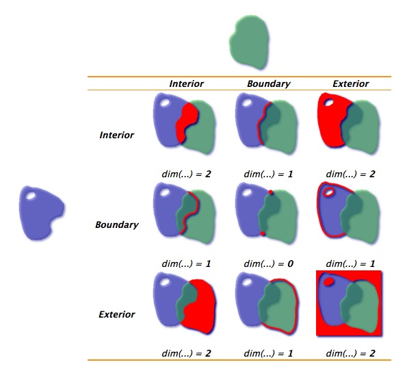

https://postgis.net/workshops/postgis-intro/de9im.html

## Predykat a model DE-9IM

**Predykat przestrzenny:**

- sprawdza czy zachodzi dana relacja
- zwraca wartość logiczną
- jest prosty w interpretacji

**Model DE-9IM:**

- szczegółowa analiza topologiczna
- zwraca macierz 9-komórkową
- jest bardziej złożony i trudniejszy w interpretacji